# STA141A Final Project Report

Predicting Notable Wildfire Frequency in the United States

Navid Rahimi

March 16, 2026

## Abstract

Wildfires are one of the most destructive natural hazards in the United States, and predicting when and where notable fires will occur can be crucial for fire departments across the nation. In this report various models used to predict the monthly occurrence of notable wildfires (≥ 300 acres) across U.S. states are built and compared. With the use of 100,000 wildfire records from the years 1992 to 2015, a grid of states and years/months consisting of 14,976 observations are created as well, where about 6% of cells contain a notable fire. The predictors, total small fire count, mean small fire size, and amount of fires caused by lightning, are made only from smaller fires below 300 acres to prevent target leakage. Through exploratory analysis, we can also confirm there’s a significant peak in fire activity during summer, along with a slight upward trend, and a heavy concentration in Western states. In the report, two specific models are constructed and compared: a baseline logistic regression model with state and month indicator variables, and a random forest model fitted with class imbalance weighting. Both of the models are evaluated by training on the wildfire data and testing on future years across four time windows. The logistic regression model achieves a pooled AUC of 0.900, outperforming the random forest (0.863) in every validation fold, showing the significance of regular seasonal and geographic structure in the predictions.

## 1. Data Preprocessing

### 1.1 Dataset Overview

The raw dataset of 100,000 recorded observations is drawn from the *188 Million US Wildfires* database, spanning wildfire incidents recorded across the United States from **1992 to 2015**. Each row represents one fire event and includes the ignition location (latitude/longitude, state, county), discovery and containment dates, final burned area (acres), stated ignition cause, and land-ownership classification. In total the raw file contains **39 variables**.

### 1.2 Date Conversion

`DISCOVERY_DATE` is stored as a JDN, and to extract the calendar year and month required for temporal aggregation we convert each JDN to an R `Date` object.

### 1.3 Missing-Data Assessment

Before filtering or constructing the modeling dataset we need to check for missing values. Table 1 summarizes variables with at least one missing value.

Table 1. Variables with missing values in the raw dataset (n = 100,000).

| Variable | N Missing | % Missing |
| --- | --- | --- |
| COMPLEX_NAME | 99751 | 99.8% |
| MTBS_ID | 99423 | 99.4% |
| MTBS_FIRE_NAME | 99423 | 99.4% |
| ICS_209_INCIDENT_NUMBER | 98634 | 98.6% |
| ICS_209_NAME | 98634 | 98.6% |
| FIRE_CODE | 82817 | 82.8% |
| LOCAL_FIRE_REPORT_ID | 77654 | 77.7% |
| CONT_TIME | 51813 | 51.8% |
| FIRE_NAME | 51227 | 51.2% |
| CONT_DATE | 47483 | 47.5% |
| CONT_DOY | 47483 | 47.5% |
| DISCOVERY_TIME | 46972 | 47% |
| LOCAL_INCIDENT_ID | 43621 | 43.6% |
| COUNTY | 35991 | 36% |
| FIPS_CODE | 35991 | 36% |
| FIPS_NAME | 35991 | 36% |

**Key observations and handling decisions:**

- **Administrative / reporting identifiers** (`FIRE_CODE`, `LOCAL_FIRE_REPORT_ID`, `ICS_209_*`, `MTBS_*`, `COMPLEX_NAME`) are missing in 50–100% of records. These fields describe reporting bureaucracy rather than fire characteristics and are **excluded** from all downstream analyses.
- **County-level geographic identifiers** (`COUNTY`, `FIPS_CODE`, `FIPS_NAME`) are absent for **~36% of records**. This high rate motivates the use of U.S. *state* as the spatial unit (see Section 1.5).
- **`DISCOVERY_TIME`** (47% missing) and **`CONT_DATE`/`CONT_TIME`** (47–52% missing) are not used as predictors, avoiding substantial imputation.
- After applying these decisions the final modeling dataset contains **no missing values**.

### 1.4 Notable-Fire Cutoff

The size distribution of recorded fires is very heavily right-skewed. The median burned area is only a **single acre** and more than 85% of fires burned fewer than 10 acres. If all the fires were included in the prediction target, it would create extreme class imbalance and would combine unimportant ignitions, most of which extinguish themselves or are immediately suppressed, with fires that are operationally and ecologically significant.

To focus the prediction task on fires that matter, we filter the raw records to retain only fires with a final burned area **≥ 300 acres**. This threshold is chosen for the following reasons:

1. **Operational consistency** U.S. fire-management agencies typically define *large wildland fires* as those burning ≥ 100 acres in timber fuel types or **≥ 300 acres in grass/brush fuel types**. Since the majority of large fires in this dataset occur in the Western states’ landscapes which consist of grass and bushes, the 300 acre standard is the benchmark that can apply directly the most.
2. **Meaningful class imbalance reduction** At the state × month resolution adopted here (see Section 1.5–1.6), applying a 300 acre cutoff yields a positive class rate of approximately 6%, which is challenging but easy to control for logistic regression style models.

### 1.5 Spatial Unit

We adopt the **U.S. state** as the spatial unit for three reasons:

1. **Data completeness.** State identifiers are present for all of the 100,000 raw records; county-level FIPS codes are missing for ~36%, which would mean that we would have to either exclude or impute of a large share of the data.
2. **Avoiding excessive sparsity.** At the county × month resolution there are around 3,100 counties × 12 months × 24 years ≈ 892,800 possible cells, the overwhelming majority of which would never contain a notable fire. This extreme sparsity can make predictor aggregation unreliable and can destabilize fitting the models.
3. **Operational interpretability.** U.S. wildfire management is coordinated at the state level through the use of state forestry agencies and specific interagency coordination centers, making predictions at the state level directly actionable.

### 1.6 Space–Time Grid and Binary Outcome Variable

The modeling dataset is formed by constructing a **complete state × year-month grid** which spans over every combination of the 52 unique state codes, the 24 years (1992–2015), and all 12 calendar months, yielding **14,976 observations** (52 × 24 × 12).

For each cell $(s, t)$ we define the binary outcome:

$$Y_{s,t} = \mathbf{1}\!\left\{\text{at
least one notable wildfire (FIRE\_SIZE} \geq 300 \text{ ac) was
discovered in state } s \text{ during month } t\right\}$$

Cells in which no notable fire was discovered receive $Y = 0$; cells containing at least one notable fire receive $Y = 1$.

### 1.7 Predictor Construction

Three predictor variables are constructed by aggregating **small fires only** (FIRE_SIZE < 300 acres) inside of each state × year month cell. Notable fires (≥ 300 acres) are also not included in the predictor computation, since including them would lead to **target leakage**, meaning a cell in which a notable fire occurs (Y = 1) would have an inflated `mean_fire_size` which is driven by the fires that define the positive outcome. This can make the predictor almost perfectly correlated with the label which can lead to false high AUC values being produced. Using only small fires provides a clean signal about background fire-weather conditions and ignition pressure without encoding the outcome.

| Predictor | Description | Rationale |
| --- | --- | --- |
| `total_fires` | Count of small fires (< 300 ac) in the state-month | Captures overall ignition pressure and reporting effort without leaking the outcome |
| `mean_fire_size` | Mean burned area (acres) across small fires | Reflects average fuel / burn conditions independent of notable-fire occurrence |
| `pct_lightning` | Proportion of small fires attributed to lightning | Lightning-driven fires cluster spatially and seasonally with large-fire risk |

State-month cells for which no small fire was recorded receive predictor values of zero.

### 1.8 Final Dataset Summary

Table 2 provides a concise description of the modeling dataset used in all subsequent analyses.

Table 2. Summary of the final modeling dataset.

| Attribute | Value |
| --- | --- |
| Total observations | 14,976 |
| Spatial unit | U.S. State |
| Number of spatial units | 52 |
| Temporal unit | Calendar month |
| Year range | 1992 – 2015 |
| Months per year | 12 |
| Positive class (Y = 1: notable fire occurred) | 910 |
| Negative class (Y = 0: no notable fire) | 14,066 |
| Positive rate | 6.08% |
| Predictors | total_fires, mean_fire_size, pct_lightning |
| Missing values in final dataset | None |
| Notable-fire cutoff (FIRE_SIZE threshold) | ≥ 300 acres |

## 2. Exploratory Data Analysis

The goal of this section is to build some intuition about patterns of the occurrence of notable wildfires. It looks at its seasonality, geographic concentration, and relationship to the predictors constructed in Section 1, and uses those patterns to motivate the modeling decisions made in subsequent sections.

### 2.1 Temporal Patterns

#### 2.1.1 Seasonality

Figure 1 shows the average monthly probability that a state experiences at least one notable wildfire, aggregated across all states and all years from 1992 to 2015. The pattern also seems to reveal a pronounced **summer peak**. August has the highest positive rate (12.7%), followed closely by July (11.6%) and June (10.0%), while December is the quietest month at just 1.1% which is an **11-fold difference** between the most and least active months. A second peak can also be seen in spring (March–April, ~7–8%) which reflects the Southern Plains fire season driven by dry grassland conditions before vegetation greens up.

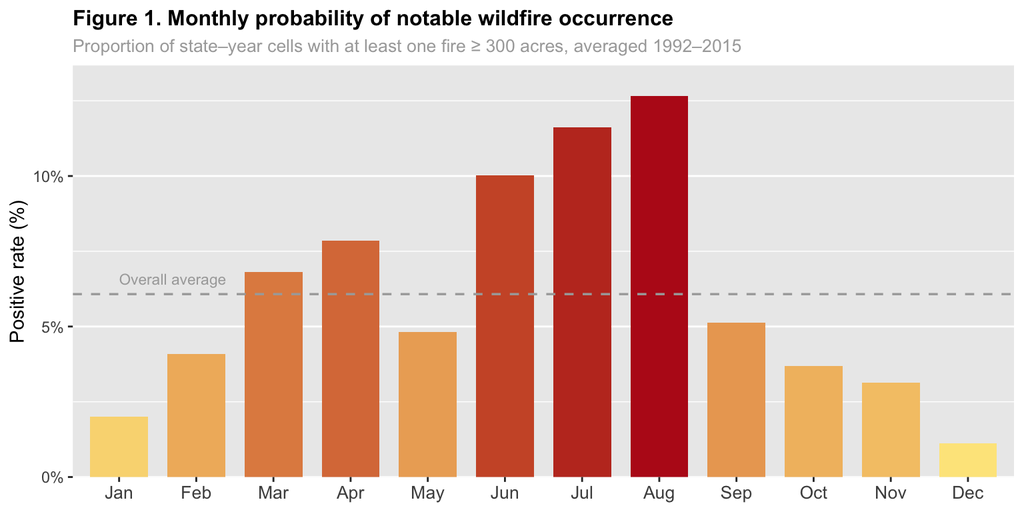

**What This Model Suggests:** The strong monthly seasonality justifies including calendar month as a predictor. A model that ignores month would systematically underestimate fire probability in summer and overestimate it in winter.

#### 2.1.2 Year-over-Year Trend

Figure 2 plots the total number of state-month cells by recording a notable fire in each year. The series changes a lot, ranging from a low of 13 cells in 1997 to a high of 64 in 2006, but it mainly displays a modest upward trend. The average count per year in the earlier period of 1992 to 2003 was 34 active cells per year, compared with the 42 in the later period (2004–2015), which is also consistent with increases in the frequency of large fires connected to the warming temperatures and prolonged drought conditions across the Western United States.

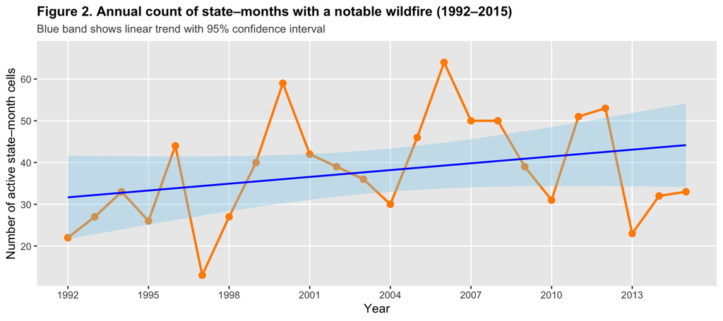

**What This Model Suggests** The positive linear trend suggests that year carries predictive signal independent of seasonal patterns. Including `YEAR` as a covariate allows the model to account for this slow-moving, climate-driven baseline shift in fire risk.

### 2.2 Spatial Distribution of Notable Fires

Figure 3 maps the total number of notable wildfires (≥ 300 acres) recorded in each contiguous U.S. state over the 24 year period that the study took place (Alaska and Hawaii are excluded from the map but included in the model). The frequency of fires is heavily concentrated in a arc on the west side. **Texas** leads with 155 notable fires, followed by **California** (118), **Idaho** (101), **Oklahoma** (89), and **New Mexico** (82). Together these five states account for roughly 40% of all notable fire occurrences in the sample despite representing a fraction of the total state–months in the modeling grid.

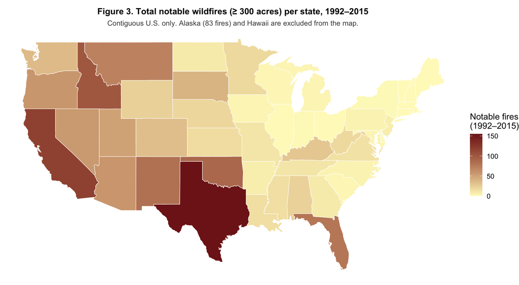

**What This Model Suggests** The strong geographic concentration of fire activity means that state identity is a powerful predictor on its own. Models should incorporate spatial information, either through state fixed effects or through state-level summary features, to capture this persistent spatial heterogeneity.

### 2.3 Predictor Distributions by Outcome

Figure 4 compares the distribution of each predictor across fire (Y = 1) and no-fire (Y = 0) state–month cells using violin plots overlaid with box plots. `total_fires` and `mean_fire_size` are log-transformed to reduce right-skew and improve readability; `pct_lightning` is shown on its original [0, 1] scale.

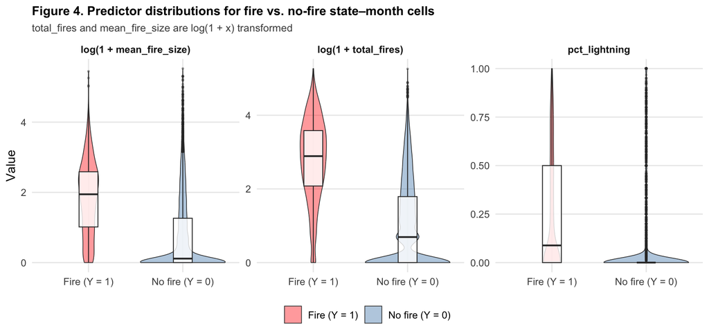

**What This Model Suggests** All of the three predictors clearly separate fire months from non-fire months, which confirms that they carry real predictive value and should be included in both models. The fact that `total_fires` and `mean_fire_size` show such a large difference on a log scale also hints that a log transformation may help the logistic regression model, while a tree-based model like random forest can handle the raw values just as naturally without any transformation.

## 3. Modeling

This section will describe the two models that were developed to predict the months with significant wildfire activity. Each of the models uses the same six predictor variables so that their performance can be compared fairly in Section 4. The first model that will be described is a logistic regression, which serves as a simple starting point. The second model described is a random forest, chosen because the patterns uncovered in Section 2 (skewed predictors, potential interactions between variables, and strong geographic and seasonal structure) suggested that a more flexible model would likely provide a better fit for the data.

### 3.1 Baseline Model: Logistic Regression

Logistic regression models the log-odds of the binary outcome as a linear combination of predictors. For each state–month cell $(s, t)$, the model is:

$$\text{logit}\!\left[P(Y_{s,t}=1)\right]
= \beta_0 + \beta_1\,\text{YEAR} +
\sum_{m=2}^{12}\alpha_m\,\mathbf{1}[\text{MONTH}=m] +
\sum_{j=2}^{52}\gamma_j\,\mathbf{1}[\text{STATE}=j] +
\beta_2\,\log(1+\text{total\_fires}) +
\beta_3\,\log(1+\text{mean\_fire\_size}) +
\beta_4\,\text{pct\_lightning}$$

The model has **67 free parameters**: an intercept, a slope for `YEAR`, eleven month indicators (January as reference), fifty-one state indicators (Alaska as reference), and three slopes for the continuous predictors.

Since the continuous predictors `total_fires` and `mean_fire_size` enter on a $\log(1+x)$ scale and because they are heavily right-skewed, the log transformation brings them closer to linearity. `pct_lightning` is already bounded on $[0,1]$ and enters untransformed. Month and state fixed effects are included as indicator variables, which directly capture the seasonal and geographic heterogeneity identified in Sections 2.1 and 2.2.

The predicted probability for a new observation is recovered by the inverse logit:

$$\hat{P}(Y_{s,t}=1) = \frac{1}{1 +
e^{-\hat{\eta}_{s,t}}}$$

where $\hat{\eta}_{s,t}$ is the estimated linear predictor.

### 3.2 Model of Choice: Random Forest

A random forest is an ensemble of $B$ binary decision trees. Each tree $T_b$ is grown on a bootstrap sample of the training data, and at every candidate split only a random subset of $m$ predictors is considered. The predicted fire probability for a new observation $\mathbf{x}$ is the average of the individual tree probability estimates:

$$\hat{P}(Y_{s,t}=1 \mid \mathbf{x}) =
\frac{1}{B}\sum_{b=1}^{B} T_b(\mathbf{x};\,\Theta_b)$$

where $\Theta_b$ encodes the bootstrap sample indices and the random feature subset drawn at each split of tree $b$. Key hyperparameter choices are as follows:

- **Number of trees ($B$):** 500. Sufficient for stable probability estimates with negligible variance from the randomisation; increasing beyond 500 provides diminishing returns.
- **Features per split ($m$):** $\lfloor\sqrt{p}\rfloor = \lfloor\sqrt{6}\rfloor = 2$. The standard default for classification, ensuring that each tree uses a diverse, decorrelated subset of predictors.
- **Class weights:** The positive class ($Y=1$) is upweighted by a factor of $14{,}066 / 910 \approx 15.5$ to compensate for the 15:1 class imbalance, preventing the ensemble from defaulting to the majority class.

**Justification.** Three specific findings from the EDA directly motivate the choice of random forest over logistic regression:

1. *Non-linearity and skewness.* The violin plots in Figure 4 show that `total_fires` and `mean_fire_size` have heavily right-skewed distributions with different shapes between fire and non fire months. Decision trees handle this naturally by splitting on raw values so there isn’t a need to log transform these predictors beforehand.
2. *Interactions.* Fire risk doesn’t behave the same way across all of the places and times. It has a high lightning rate and is far more dangerous in a dry Western state in August than in a humid Eastern state in February. Random forests pick up on these kinds of combined effects on their own as they build each tree, without the need to do any extra work from the analyst.
3. *High-cardinality categorical predictors.* With 52 states and 12 months in the data, there is a lot of categorical strucutre to account for. Random forests handle this naturally, while a logistic regression model needs over 60 indicator variables to represent the same information. This can lead to instability when some of those variables are correlated with each other.

### 3.3 Model Specification Summary

Table 3 summarises the key design decisions for both models side by side.

Table 3. Specification summary for both predictive models.

| Attribute | Logistic Regression | Random Forest |
| --- | --- | --- |
| Model type | Generalised linear model (binomial) | Ensemble of 500 decision trees (ranger) |
| Outcome | Binary: notable_fire (0 / 1) | Binary: notable_fire (no / yes) |
| Predictors | YEAR, MONTH, STATE, log_total_fires, log_mean_fire_size, pct_lightning | YEAR, MONTH, STATE, total_fires, mean_fire_size, pct_lightning |
| Continuous predictor encoding | log(1 + x) transformation applied | Raw values (no transformation needed) |
| Spatial / temporal structure | Explicit indicator variables (11 month + 51 state dummies) | Learned implicitly through tree splits |
| Class imbalance handling | None required | Positive-class weight ≈ 15.5× |
| Key hyperparameters | None (MLE via IRLS) | B = 500 trees, mtry = 2, class weight = 15.5 |
| Free parameters | 67 | Non-parametric |
| Interpretability | High — signed coefficients on log-odds scale | Moderate — variable importance scores available |

## 4. Model Fitting and Validation

Both models are evaluated using **time-series cross-validation**, which is the right approach here because the data has a natural time order that needs to be respected. In each fold, the model is trained only on past years and tested on future ones, so it never gets to peek at data from ahead in time. Regular k-fold cross-validation is avoided here because randomly mixing the data into folds could let the model train on 2014 data and then be tested on 1998 data, which would paint an unrealistically optimistic picture of how well it actually performs.

The 24 available years are partitioned into four folds with a fixed 2-year test window:

| Fold | Training years | Test years |
| --- | --- | --- |
| 1 | 1992 – 2007 | 2008 – 2009 |
| 2 | 1992 – 2009 | 2010 – 2011 |
| 3 | 1992 – 2011 | 2012 – 2013 |
| 4 | 1992 – 2013 | 2014 – 2015 |

At each fold both models are re-fitted from scratch on the training subset and scored on the held-out test subset. Out-of-fold predicted probabilities are collected across all four folds and used to compute per-fold AUC, an overall (pooled) AUC, and the ROC curves shown in Figures 5 and 6.

### 4.1 Cross-Validated AUC by Fold

Table 4 reports the held-out AUC for both models in each test period, along with the overall pooled AUC. The pooled AUC treats the four test windows as one continuous held-out set and is the primary summary metric.

Table 4. Cross-validated AUC by test period for both models.

| Test period | Logistic Regression | Random Forest | LR - RF |
| --- | --- | --- | --- |
| 2008-2009 | 0.892 | 0.852 | 0.040 |
| 2010-2011 | 0.903 | 0.883 | 0.020 |
| 2012-2013 | 0.887 | 0.835 | 0.052 |
| 2014-2015 | 0.924 | 0.885 | 0.039 |
| Overall (pooled) | 0.900 | 0.863 | 0.037 |

### 4.2 Diagnostic Plots

#### 4.2.1 Cross-Validated AUC Over Time

Figure 5 plots the per-fold AUC for both of the models across the four test periods. The dashed line marks the AUC of a random classifier (0.5). Logistic regression achieves higher AUC than the random forest in every fold (pooled AUC 0.900 vs. 0.863), a result that is consistent with the structure of this dataset: the space–time grid has strong and regular seasonal and geographic patterns that the explicit month and state fixed effects in the logistic model capture very efficiently. Both of the models also show some variation from fold to fold, which lines up with the year-to-year variation in fire activity seen in Figure 2.

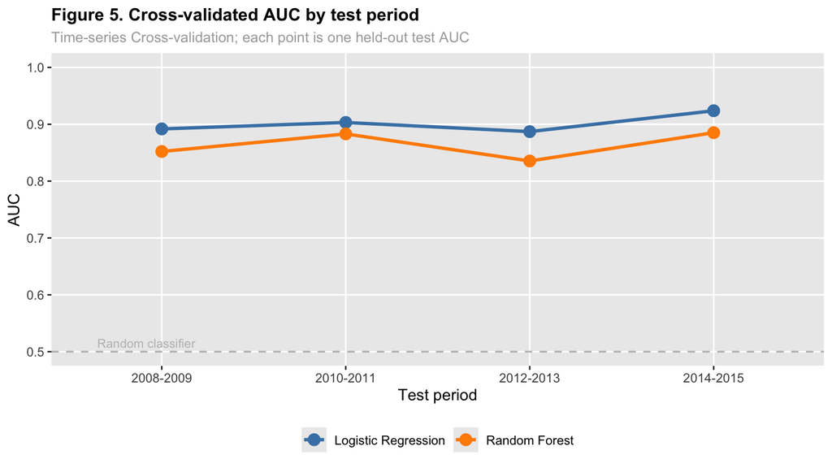

#### 4.2.2 ROC Curves (Pooled Out-of-Fold Predictions)

Figure 6 shows the ROC curves for both models using predictions pooled across all of the four test windows. Each point on the curve represents a different decision threshold which is used to classify a state-month as a fire or non fire month, and the area under the curve captures how well the model separates the two classes overall. A perfect model would hug the upper-left corner, while the diagonal line represents a model that would guess randomly. The curve on the logistic regression seems to run above the random forest curve for most of the plot, which lines up with its higher pooled AUC of 0.900 compared to 0.863 which, given the data, makes sense. Fire risk typically follows strong seasonal and geographic patterns that a typical straightforward linear model picks up on very naturally when predicting into future years.

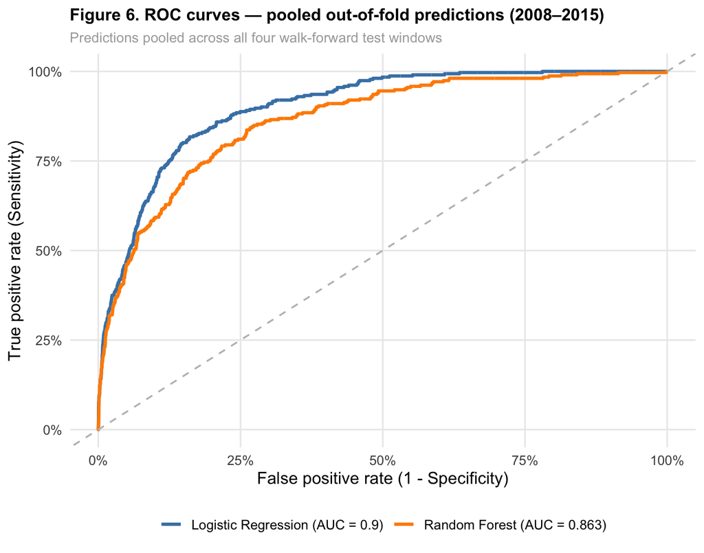

## 5. Summary

### 5.1 Key Findings from Exploratory Analysis

We found three dominant trends based on the exploratory data. First, the occurance of wildfires in the US seems to be heavily based on the seasons. The probability that a U.S. state experiences at least one notable fire peaks in August (12.7%) and reaches its lowest in December (1.1%). A second peak in spring during March and April also matches the Southern Plains dry grass fire season. Secondly, fire activity looks to be highly concentrated geographically. Five Western and Southern states (Texas, California, Idaho, Oklahoma, and New Mexico) account for roughly 40% of all notable fires even though they represent a small fraction of the total cells in the state month grid. This continuous spatial heterogeneity shows us that a model has to account for baseline differences at the state level. Finally, a slight but consistent upward trend can be seen over the study period. The average amount of active cells per year rose from 34, in 1992 to 2003, to 42, from 2004 to 2015, which seems to also be consistent with increases in the amount of large fires being linked to warming temperatures and prolonged drought.

These patterns are also reinforced by the predictor distributions. The state-month cells that have a notable fire have much higher counts of small fires, larger average sizes of small fires, and a higher proportion of fires caused by lightning compared with the non fire cells. This separation across all of the three predictors confirms that background fire activity and the way the fire starts can genuinely improve predictions about the likelihood of a notable fire in a given place and time.

### 5.2 What the Predictive Models Capture

Both the logistic regression and random forest models are able to identify fire months from the non fire months correctly on future years which they haven’t been trained on. The logistic regression achieves a pooled AUC of 0.900 across four walk forward validation folds, and the random forest achieves 0.863. An AUC well above 0.5 means that, when randomly pairing a state-month that did experience a notable fire with one that did not, the model assigns a higher predicted probability to the fire cell the vast majority of the time.

The logistic regression model performs better than the random forest one here because the data is driven mainly by large, predictable patterns such as, which season it is, which state, and what year, that a simple linear model typically handles very well. The random forest model seems to be better for finding hidden interactions in the data, but those interactions don’t add much beyond what the seasonal and geographic patterns already tell us, and the model needs more data than each training window provides to learn them reliably.

### 5.3 Limitations and Future Directions

Through my research and analysis, there are several limitations worth noting. Using U.S. States as the spatial unit can be broad, and smaller more specific units such as counties could better capture local fuel conditions and topographic fire risk. The predictor set is currently restricted to variables which can be derived from the fire record itself and being able to incorporate external data, especially temperature, precipitation, drought indicators, and vegetation maps, would likely produce substantially better forecasts. Finally, the 100,000 record subset used here may undersample less common fire events in states and years with low activity. Using the full 188 million record dataset could improve both predictor reliability and model stability. Nonetheless, even with these limitations, the models show that the fire records alone are enough to predict which state-months are at risk for a notable wildfire.